# Taller de agentes y problemas de búsqueda

Demostración docente · Formular, representar y resolver

## Propósito

Construiremos una solución completa para un **agente de reparto** dentro de un campus. Debe llevar un insumo desde el depósito hasta un laboratorio.

El centro del trabajo no es el grafo ni la programación de un algoritmo desde cero: es **formular un problema de búsqueda para un agente**, decidir qué cuenta como una buena solución y usar una biblioteca para ejecutarla sobre un entorno representado explícitamente.

## Actividad inicial · Mirar la estrategia

Abrí el [Simulador de algoritmos de búsqueda](https://jumafernandez.github.io/simulador-busqueda-ia/) y cargá el ejemplo **“Costos engañosos (BFS ≠ UCS)”**.

1. Ejecutá BFS y costo uniforme paso a paso.
2. Identificá qué nodos se exploran primero en cada caso.
3. Anticipá cuál usarías si el agente sólo necesitara llegar; cuál si debiera minimizar el costo de traslado.

El simulador permite observar el comportamiento interno. En Python nos concentraremos en modelar y resolver problemas con `NetworkX`.

## 1. Formular el problema del agente

| Componente | Decisión para este caso |
| --- | --- |
| Agente | Repartidor autónomo del campus |
| Estados | Ubicación actual del agente |
| Estado inicial | `Depósito` |
| Percepción | Ubicación actual y conexiones habilitadas desde ella |
| Acciones | Desplazarse por una conexión saliente disponible |
| Modelo de transición | La acción lleva al nodo de destino de la conexión elegida |
| Objetivo | Llegar a `Laboratorio` |
| Costo | Tiempo estimado de cada traslado |

La representación como grafo dirigido es una decisión de modelado: cada lugar es un estado, cada conexión posible es una acción y el atributo `costo` representa su tiempo de recorrido.

## 2. Primer entorno: construirlo a mano

Para casos pequeños, resulta útil declarar el entorno directamente. Así podemos discutir cada transición antes de leer datos externos.

```python
import matplotlib.pyplot as plt
import networkx as nx
import pandas as pd

INICIAL = "Depósito"
OBJETIVO = "Laboratorio"

conexiones = [
    ("Depósito", "Recepción", {"costo": 2}),
    ("Depósito", "Archivo", {"costo": 1}),
    ("Recepción", "Laboratorio", {"costo": 2}),
    ("Archivo", "Laboratorio", {"costo": 4}),
    ("Archivo", "Taller", {"costo": 1}),
    ("Taller", "Laboratorio", {"costo": 1}),
]

grafo_manual = nx.DiGraph()
grafo_manual.add_edges_from(conexiones)
```

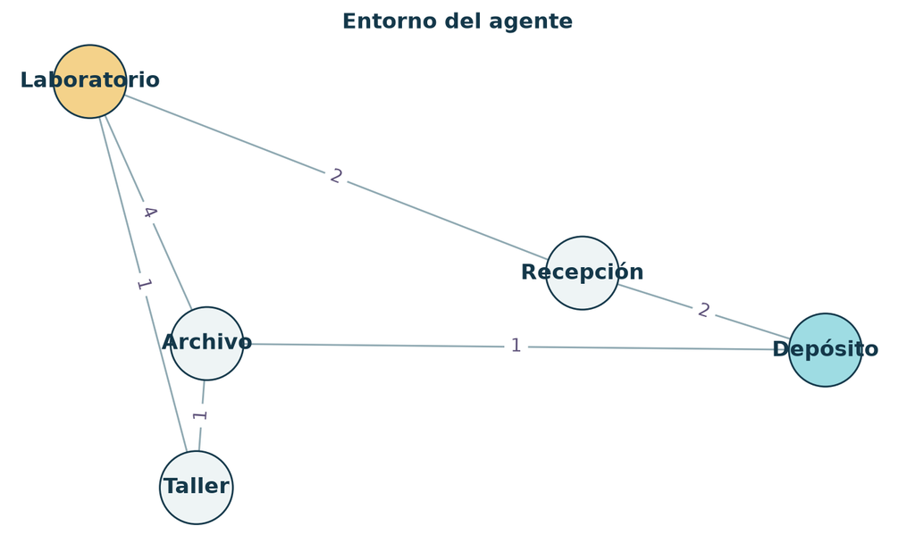

```python
def dibujar_entorno(grafo, inicial, objetivo, camino=None, titulo="Entorno del agente"):
    posicion = nx.spring_layout(grafo, seed=14)
    colores = ["#eef4f5" for _ in grafo.nodes]
    colores[list(grafo.nodes).index(inicial)] = "#9edce3"
    colores[list(grafo.nodes).index(objetivo)] = "#f4d28a"
    aristas_camino = list(zip(camino, camino[1:])) if camino else []

    plt.figure(figsize=(9, 5))
    nx.draw_networkx_nodes(grafo, posicion, node_color=colores, edgecolors="#14384a", node_size=1700)
    nx.draw_networkx_labels(grafo, posicion, font_weight="bold", font_color="#14384a")
    nx.draw_networkx_edges(grafo, posicion, edge_color="#8ea8b1", arrows=True, arrowsize=18)
    nx.draw_networkx_edges(grafo, posicion, edgelist=aristas_camino, edge_color="#2f91a5", width=3, arrows=True, arrowsize=18)
    nx.draw_networkx_edge_labels(grafo, posicion, edge_labels=nx.get_edge_attributes(grafo, "costo"), font_color="#5d5179")
    plt.title(titulo, color="#14384a", weight="bold")
    plt.axis("off")
    plt.show()

dibujar_entorno(grafo_manual, INICIAL, OBJETIVO)
```

## 3. Resolver según el criterio de calidad

Si todas las acciones tienen el mismo valor, buscamos una secuencia con la menor cantidad de pasos.

```python
camino_menos_pasos = nx.shortest_path(grafo_manual, source=INICIAL, target=OBJETIVO)
camino_menos_pasos
```

```
['Depósito', 'Recepción', 'Laboratorio']
```

Pero en este caso los desplazamientos tienen costos distintos. Para minimizar el tiempo acumulado usamos Dijkstra e indicamos qué atributo contiene el costo.

```
Camino de menor costo: Depósito → Archivo → Taller → Laboratorio
Costo total: 3
```

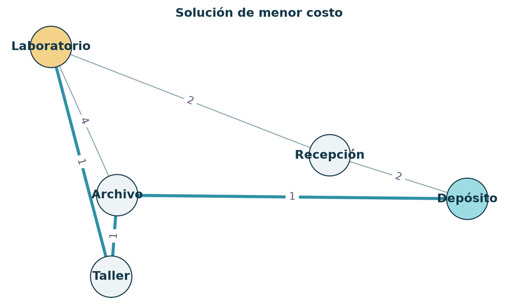

```python
camino_menor_costo = nx.dijkstra_path(grafo_manual, INICIAL, OBJETIVO, weight="costo")
costo_menor = nx.dijkstra_path_length(grafo_manual, INICIAL, OBJETIVO, weight="costo")

print("Camino de menor costo:", " → ".join(camino_menor_costo))
print("Costo total:", costo_menor)
dibujar_entorno(grafo_manual, INICIAL, OBJETIVO, camino_menor_costo, "Solución de menor costo")
```

> La biblioteca ejecuta la estrategia; nuestra responsabilidad sigue siendo formular correctamente estados, acciones, objetivo y criterio de costo. Un algoritmo correcto sobre un modelo equivocado no resuelve el problema del agente.

## 4. Segundo entorno: cargar conexiones desde un CSV

En un problema más grande no queremos editar código cada vez que cambia el mapa. Un CSV de aristas separa los datos del programa.

```python
ARCHIVO = "datos/demo_mensajero.csv"
aristas = pd.read_csv(ARCHIVO)
aristas
```

|  | origen | destino | costo |
| --- | --- | --- | --- |
| 0 | Base | Recepción | 2 |
| 1 | Base | Archivo | 1 |
| 2 | Recepción | Laboratorio | 2 |
| 3 | Archivo | Laboratorio | 4 |
| 4 | Archivo | Taller | 1 |
| 5 | Taller | Laboratorio | 1 |
| 6 | Laboratorio | Servidor | 3 |
| 7 | Taller | Servidor | 7 |

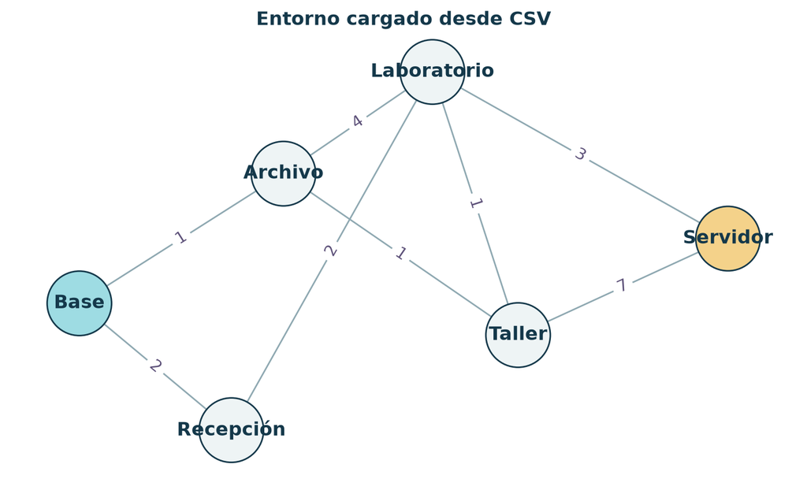

```python
grafo_csv = nx.from_pandas_edgelist(
    aristas,
    source="origen",
    target="destino",
    edge_attr="costo",
    create_using=nx.DiGraph,
)

dibujar_entorno(grafo_csv, "Base", "Servidor", titulo="Entorno cargado desde CSV")
```

```python
def resolver_agente(grafo, inicial, objetivo, criterio="pasos"):
    try:
        if criterio == "pasos":
            camino = nx.shortest_path(grafo, source=inicial, target=objetivo)
            return {"estado": "solución encontrada", "camino": camino, "pasos": len(camino) - 1}
        if criterio == "costo":
            camino = nx.dijkstra_path(grafo, inicial, objetivo, weight="costo")
            costo = nx.dijkstra_path_length(grafo, inicial, objetivo, weight="costo")
            return {"estado": "solución encontrada", "camino": camino, "costo": costo}
        raise ValueError("El criterio debe ser 'pasos' o 'costo'.")
    except nx.NetworkXNoPath:
        return {"estado": "sin solución", "camino": None}

resolver_agente(grafo_csv, "Base", "Servidor", criterio="costo")
```

```
{'estado': 'solución encontrada',
 'camino': ['Base', 'Archivo', 'Taller', 'Laboratorio', 'Servidor'],
 'costo': 6}
```

## 5. Qué aprendimos del caso

- El problema se define desde la tarea del agente: estado, percepción, acciones, transición, objetivo y costo.
- El grafo es una representación útil del entorno; no sustituye la formulación del problema.
- Un CSV permite modificar el entorno sin alterar la lógica de resolución.
- La elección de búsqueda depende del criterio de calidad: menos pasos no siempre significa menor costo.
- Si no existe una ruta, el resultado también es información relevante para el agente.

En el desafío siguiente se aplicará el mismo proceso sobre un nuevo contexto de inspección. La novedad estará en la formulación y el análisis, no en copiar una implementación de algoritmos.